# The ‘Hello World’ of Deep Learning

# Welcome to your first deep learning module!

This module is designed to provide you an introduction to deep learning and some of the key components that make DL algorithms run. Throughout this case study you will learn:

- What tensors are
- What makes up a basic feedforward neural network architecture
- What forward and backward passes are
- How a neural network learns via backpropagation and batch processing

In doing so you will run your first neural network with one of the most famous benchmark data sets –> MNIST.

# Installation

Normally, you will be starting out from scratch and need to install and set up keras on your own laptop. First, you need to install keras from CRAN. Once the package is installed, you need to install the Keras and TensorFlow Python packages, which is what the R Keras and TensorFlow packages communicate with. keras simplifies this with `install_keras()` which allows for:

- both GPU & CPU options setups
- installation in a virtual or conda environment
- setup for Theano & CNTK backends rather than TensorFlow

```r
# install keras
# install.packages("keras")

# default CPU-based installations of Keras and TensorFlow
# install_keras()

# for GPU capabilities
# install_keras(tensorflow = "gpu")
```

This installation can be quite simple, and it can get quite complex depending on your current system setup and needs.

For this workshop we will be using a cloud environment to ensure we are all operating in common environment and Keras and TensorFlow have already been installed.

Let’s load the `keras` package along with a couple other packages we’ll use.

```r
knitr::opts_chunk$set(echo = TRUE)

# Install package from CRAN if necessary
# install.packages('keras')

library(keras)     # for deep learning
library(dplyr)     # for minor data wrangling
library(ggplot2)   # for plotting
```

# Part 1: Data Preparation

## Obtain data

`keras` has many built in data sets (or functions to automatically install data sets). Check out what data is available with `dataset_` + tab.

We’re going to use the *MNIST* data set which is the “hello world” for learning deep learning!

```r
mnist <- dataset_mnist()
str(mnist)
```

```
List of 2
 $ train:List of 2
  ..$ x: int [1:60000, 1:28, 1:28] 0 0 0 0 0 0 0 0 0 0 ...
  ..$ y: int [1:60000(1d)] 5 0 4 1 9 2 1 3 1 4 ...
 $ test :List of 2
  ..$ x: int [1:10000, 1:28, 1:28] 0 0 0 0 0 0 0 0 0 0 ...
  ..$ y: int [1:10000(1d)] 7 2 1 0 4 1 4 9 5 9 ...
```

When we work with keras:

- training and test sets need to be independent
- features and labels (aka target, response) need to be independent
- use `%<-%` for *object unpacking* (see `?zeallot::%<-%`)

```r
c(c(train_images, train_labels), c(test_images, test_labels)) %<-% mnist
```

## Data structure

Our training images (aka features) are stored as a 3D array

- 60,000 images consisting of a…
- 28x28 matrix with…
- values ranging from 0-255 representing gray scale pixel values.

```r
dim(train_images)
```

```
[1] 60000    28    28
```

Check out the first digit

```r
digit <- train_images[1,,]
digit
```

```
      [,1] [,2] [,3] [,4] [,5] [,6] [,7] [,8] [,9] [,10] [,11] [,12] [,13] [,14] [,15] [,16] [,17] [,18] [,19] [,20] [,21] [,22]
 [1,]    0    0    0    0    0    0    0    0    0     0     0     0     0     0     0     0     0     0     0     0     0     0
 [2,]    0    0    0    0    0    0    0    0    0     0     0     0     0     0     0     0     0     0     0     0     0     0
 [3,]    0    0    0    0    0    0    0    0    0     0     0     0     0     0     0     0     0     0     0     0     0     0
 [4,]    0    0    0    0    0    0    0    0    0     0     0     0     0     0     0     0     0     0     0     0     0     0
 [5,]    0    0    0    0    0    0    0    0    0     0     0     0     0     0     0     0     0     0     0     0     0     0
 [6,]    0    0    0    0    0    0    0    0    0     0     0     0     3    18    18    18   126   136   175    26   166   255
 [7,]    0    0    0    0    0    0    0    0   30    36    94   154   170   253   253   253   253   253   225   172   253   242
 [8,]    0    0    0    0    0    0    0   49  238   253   253   253   253   253   253   253   253   251    93    82    82    56
 [9,]    0    0    0    0    0    0    0   18  219   253   253   253   253   253   198   182   247   241     0     0     0     0
[10,]    0    0    0    0    0    0    0    0   80   156   107   253   253   205    11     0    43   154     0     0     0     0
[11,]    0    0    0    0    0    0    0    0    0    14     1   154   253    90     0     0     0     0     0     0     0     0
[12,]    0    0    0    0    0    0    0    0    0     0     0   139   253   190     2     0     0     0     0     0     0     0
[13,]    0    0    0    0    0    0    0    0    0     0     0    11   190   253    70     0     0     0     0     0     0     0
[14,]    0    0    0    0    0    0    0    0    0     0     0     0    35   241   225   160   108     1     0     0     0     0
```

[output cut: 43 more lines]

Lets plot the first digit and compare to the above matrix

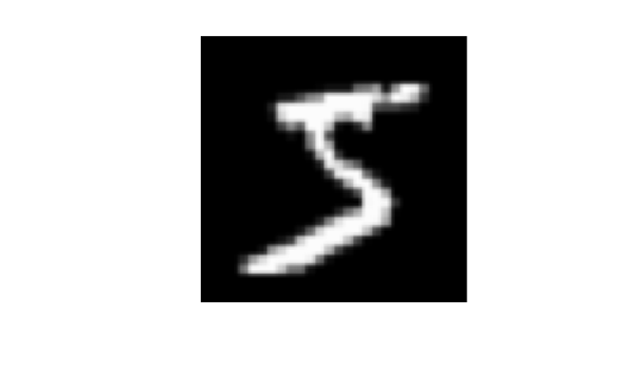

```r
plot(as.raster(digit, max = 255))
```

Now lets check out the first 100 digits

```r
par(mfrow = c(10, 10), mar = c(0,0,0,0))
for (i in 1:100) {
  plot(as.raster(train_images[i,,], max = 255))
}
```

[output not shown]

## Reshape data:

Our current data structure is incompatible for modeling a basic neural network

```r
str(train_images)
str(test_images)
```

We need to reshape these into a 2D *tensor*

```r
train_images <- array_reshape(train_images, c(60000, 28 * 28))
test_images <- array_reshape(test_images, c(10000, 28 * 28))

str(train_images)
str(test_images)
```

## Normalize data:

Our feature values range from 0-255. For our purposes we want to normalize these values to be between 0-1. We’ll discuss why this is important later.

```r
train_images <- train_images / 255
test_images <- test_images / 255
```

## Prepare labels:

Our response data are currently 1D arrays (60,000 vectors of length 1) with the actual digit the image represents.

```r
str(train_labels)
str(test_labels)
```

We could use that structure for our response but, often, for classification problems we’ll reformat with `to_categorical()`:

```r
train_labels <- to_categorical(train_labels)
test_labels <- to_categorical(test_labels)

head(train_labels)
```

# Part 2: Training a DL model

Nearly all DL models have a very similar training process:

1. Define the network architecture
2. Define network compilation
3. Execute training loop

## 1. Define the network architecture

```r
network <- keras_model_sequential() %>%
  layer_dense(units = 512, activation = 'relu', input_shape = ncol(train_images)) %>%
  layer_dense(units = 10, activation = 'softmax')
```

You can view a summary of the network

```r
summary(network)
```

## 2. Define network compilation

```r
network %>% compile(
  loss = "categorical_crossentropy",
  optimizer = "rmsprop",
  metrics = c("accuracy")
)
```

When training the model in RStudio, you will see a real-time plot of the loss metric along with any other metrics identified to track.

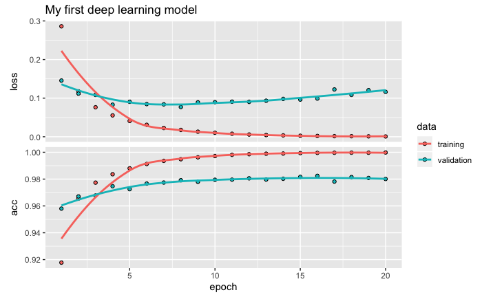

```r
plot(history) + ggtitle("My first deep learning model")
```

# YOUR TURN!

1. Identify the optimal number of epochs from our previous model
2. Fill in the blanks below and re-run the model

```r
network <- keras_model_sequential() %>%
  layer_dense(units = 512, activation = _____, input_shape = ncol(train_images)) %>%
  layer_dense(units = 10, activation = _____)

network %>% compile(
  optimizer = "rmsprop",
  loss = _____,
  metrics = c("accuracy")
)

# use optimal number of epochs
history <- network %>%
  fit(train_images, train_labels,
      batch_size = 128, epochs = _____,
      validation_split = 0.2)
```

# Part 3: Evaluate results

## Metrics

```r
metrics <- network %>% evaluate(test_images, test_labels)
metrics
```

```
$loss
[1] 0.0913427

$acc
[1] 0.9831
```

```r
# Test set accuracy rate
metrics$acc
```

```
[1] 0.9831
```

```r
# Test set error rate
1 - metrics$acc
```

```
[1] 0.0169
```

## Predictions

You can predict either the probability of each class. Note that column 1 is for digit 0, column 2 is for digit 1, …, column 10 is for digit 9.

```r
network %>% predict_proba(test_images[1:10,])
```

```
              [,1]         [,2]         [,3]         [,4]         [,5]         [,6]         [,7]         [,8]         [,9]
 [1,] 9.706012e-18 2.725779e-22 1.644350e-14 2.200245e-11 1.578321e-27 4.140327e-18 6.490741e-30 1.000000e+00 1.335674e-15
 [2,] 1.446519e-22 6.196155e-11 1.000000e+00 2.792829e-20 5.946452e-38 4.122359e-19 8.874683e-19 2.104465e-36 3.360209e-20
 [3,] 1.368182e-13 9.999994e-01 3.080502e-08 3.036418e-12 4.078695e-10 9.505252e-10 3.687536e-10 1.819181e-07 3.594158e-07
 [4,] 1.000000e+00 2.125295e-21 7.304856e-10 4.463652e-16 8.665275e-17 3.164372e-15 6.153535e-10 1.496445e-09 6.399755e-20
 [5,] 1.869886e-13 7.862369e-21 4.186689e-12 1.691330e-16 9.999839e-01 1.019575e-15 2.961962e-13 2.032234e-08 3.833455e-11
 [6,] 3.357652e-16 9.999996e-01 1.782980e-12 1.173408e-14 5.145136e-11 2.332006e-15 1.191854e-15 3.397347e-07 1.810080e-09
 [7,] 6.071946e-25 3.819592e-18 1.197939e-16 1.680096e-18 1.000000e+00 2.217853e-11 2.496100e-16 8.565311e-11 8.197675e-09
 [8,] 1.411251e-19 3.291233e-13 1.047330e-10 3.913719e-08 1.265386e-07 4.632675e-11 3.740855e-20 5.199991e-11 1.918966e-12
 [9,] 5.138406e-23 6.631563e-28 2.554040e-16 5.994706e-21 4.561748e-14 9.932267e-01 6.773295e-03 7.002211e-22 7.407536e-12
[10,] 7.791686e-25 2.493360e-23 5.316741e-22 3.737600e-14 3.672562e-08 5.275637e-18 1.031038e-24 4.622884e-08 1.548427e-10
             [,10]
 [1,] 6.234436e-14
 [2,] 6.285962e-28
 [3,] 6.212408e-12
 [4,] 2.692545e-10
 [5,] 1.613638e-05
 [6,] 1.552132e-13
 [7,] 2.013381e-08
 [8,] 9.999999e-01
 [9,] 1.765655e-14
[10,] 9.999999e-01
```

Or you can predict the class

```r
network %>% predict_classes(test_images[1:10,])
```

```
 [1] 7 2 1 0 4 1 4 9 5 9
```

Lets get all our predictions and the actual responses for the test set.

```r
predictions <- network %>% predict_classes(test_images)
actual <- mnist$test$y
```